# How-Big-Cheatsheet

Steve Simon

September 17, 2016

# Step 0. Preliminaries

# Step 1

## An R Cheatsheet

All functions that open a device for graphics will have **height** and **width** arguments to control the size of the graph and a **pointsize** argument to control the relative font size. In knitr, you control the size of the graph with the chunk options, **fig.width** and **fig.height**. This sheet will help you with calculating the size of the graph and various parts of the graph within R.

# Step 2a

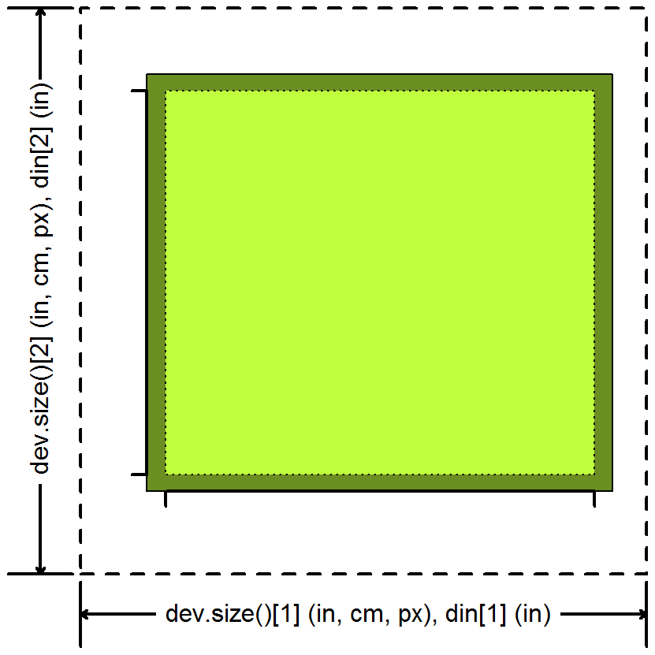

# Step 2b

## Device size

**dev.size(units)** (width, height)

**par(“din”)** *(r.o.)* (width, height) in inches

Both the **dev.size** function or **par(“din”)** will tell you the size of the graphics device, but **par(“din”)** will not be updated if you resize your graphics window. The **dev.size** function will report the size in

1. inches (**unit=“in”**), the default
2. centimeters (**units=“cm”**)
3. pixels (**units=“px”**)

Like several other **par** arguments, **din** is read only (r.o.) meaning that you cannot assign a value to it.

# Step 3a

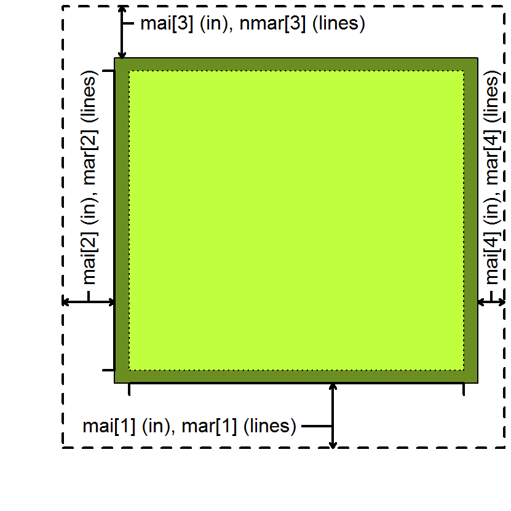

# Step 3b

## Margins

**par(“mai”)** -> (bottom, left, top, right) in inches

**par(“mar”)** -> (bottom, left, top, right) in lines

Margins provide you space for your axes, axis, labels, and titles.

If your graph has no axes or titles, you can remove the margins (and maximize the plotting region) with

**par(mar=rep(0,4))**

# Step 4a

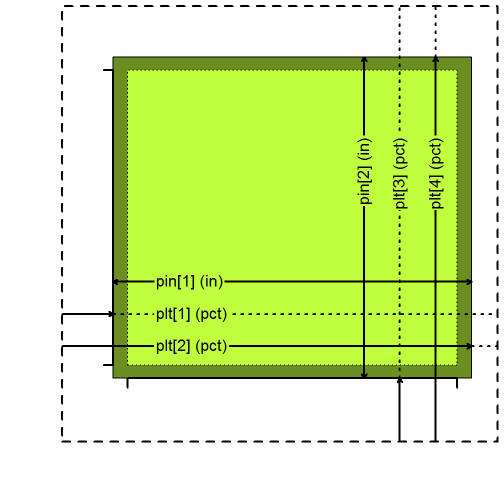

# Step 4b

## Plotting region in inches and percent

**par(“pin”)** -> (width, height) in inches

**par(“plt”)** -> (left, right, bottom, top) in percent

The **pin** argument in **par** gives you the size of the plotting region (the size of the device minus the size of the margins) in inches.

The **plt** argument gives you the percentage of the device up to the left edge of the plotting region, the right edge, the bottom edge, and the top edge. The first and third values are equivalent to the percentage of space deveoted to the left and bottom margins. Subtract the second and fourth values from 1 to get the percentage of space devoted to the right and top margins.

# Step 5a

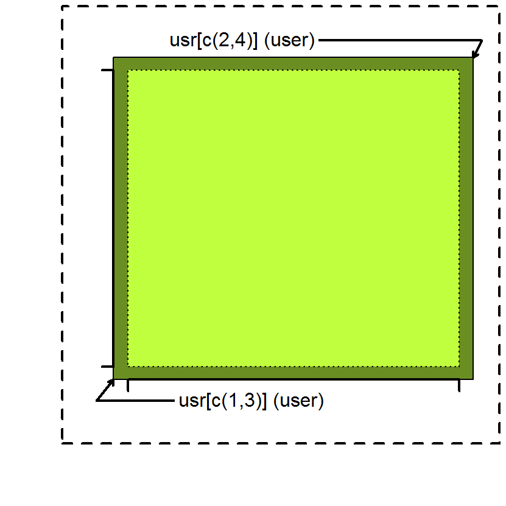

# Step 5b

## User coordinates

User coordinates are the values you use when plotting your data. Run par(“usr”) to get a vector of length 4 with the user coordinates with the minimum X value, the maximum X value, the minimum Y value, and the maximum Y value. This normally is not the same as the values specified by the xlim and ylim arguments in plot. By default, R adds and extra 4% to the plotting range so that points right on the edge do not get partially clipped. You can override this using the **xaxs=“i”** and/or the **yaxs=“i”** arguments in par.

# Step 6a

No graphs needed for this step

# Step 6b

## Getting a square graph

You can produce a square graph manually by setting the width and height to the same value and setting the margins so that the sum of the top and bottom margins equal the sum of the left and right margins. But a much easier way is to specify **pty=“s”**, which adjusts the margins so that the size of the plotting region is always square, even if you resize the graphics window.

# Steps 1-6

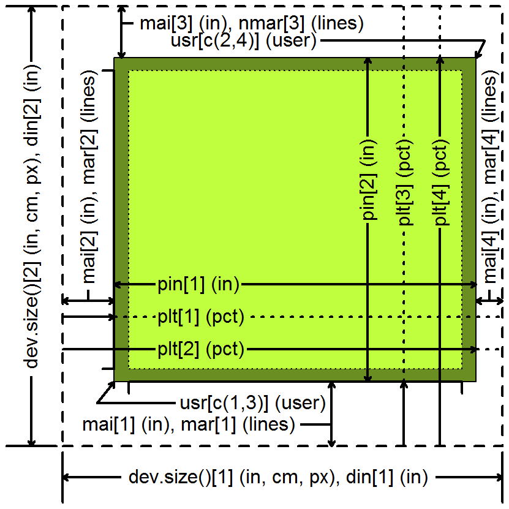

# Step 7a

## measuring pixels per user corodinate values

For many applications, you need to be able to translate user coordinates to pixels or inches. There are some cryptic shortcuts, but the simplest way is to get the range in user coordinates and measure the proportion of the graphics device devoted to the plotting region.

# Step 7b

The following code was run inside a program chunk with fig.width=1.7, fig.height=1.7.

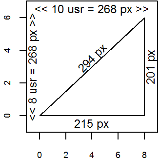

```r
par(mar=c(1.9, 1.9, 0.1, 0.1), cex=0.75,
  cex.axis=0.75, xaxs="i", yaxs="i")
plot(c(-1,9), c(-1,7), type="n")
lines(x=c(0,8,8,0), y=c(0,0,6,0)) # triangle
user.range <- par("usr")[c(2,4)] -
  par("usr")[c(1,3)]
region.pct <- par("plt")[c(2,4)] -
  par("plt")[c(1,3)]
region.px <- dev.size(units="px") * region.pct
px.per.usr <- region.px / user.range
a.px <- round(8*px.per.usr[1])
b.px <- round(6*px.per.usr[2])
c.px <- round(sqrt(a.px^2+b.px^2))
text(4, -0.5, paste(a.px,"px"))
text(8.5, 3, paste(b.px,"px"), srt=90)
text(4, 3.5, paste(c.px,"px"), srt=45)
s1 <- paste("<<", round(user.range[1]),
  "usr =", round(region.px[1]), "px >>")
s2 <- paste("<<", round(user.range[2]),
  "usr =", round(region.px[2]), "px >>")
text(4, 6.5, s1)
text(-0.5, 3, s2, srt=90)
```

# Step 8a

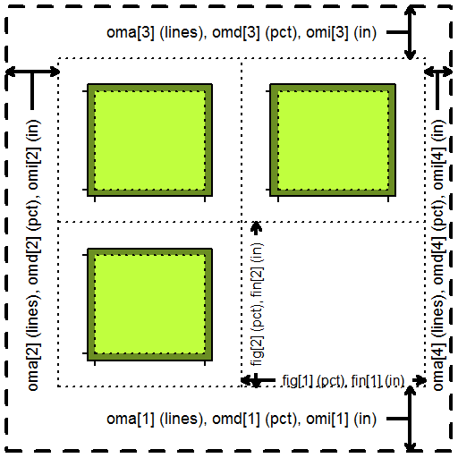

# Step 8b

## Panels

**par(“fig”)** (width, height) in pct

**par(“fin”)** (width, height) in inches

**par(“oma”)** (bottom, left, top, right) in lines

**par(“omd”)** (bottom, left, top, right) in pct

**par(“omi”)** (bottom, left, top, right) in inches

If you display multiple plots within a single graphics window (e.g., with **par(“mfrow”)** or **par(“mfcol”)** or the **layout** function), then the **fig** and **fin** arguments to **par** will tell you the size of the current subplot window in percent or inches, respectively.

Each subplot will have margins specified by **mai** or **mar**, but there are no outer margin around the entire set of plots, unless you specify them using **oma**, **omd**, or **omi**. You can place text in the outer margins using the **mtext** function with the argument **outer=TRUE**.

# Step 9a

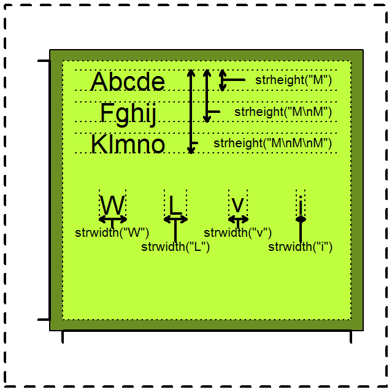

# Step 9b

## String size

**strwidth()**

**strheight()**

The text that appears inside your plot (e.g, with the **text()** function) or that appears outside your plot (e.g., your title and axis labels) can vary substantially from one plot to another.

The **strwidth** and **strheight** functions will tell you the size of a specified string in inches (**units=“inches”**), user coordinates (**units=“user”**) or as a percentage of the graphics device (**units=“figure”**).

For a single line of text, **strheight** will give you the height of the letter “M”. Watch out as the vertical size of a string will not count the part that letters that descend below the baseline (e.g., “g” or “j”).

The **strwidth** function will produce different widths to individual characters, representing the proportional spacing used by most fonts (a “W” using much more space than an “i”). For the width of a string, the **strwidth** function will sum up the lengths of the individual characters in the string.

# Step 9c

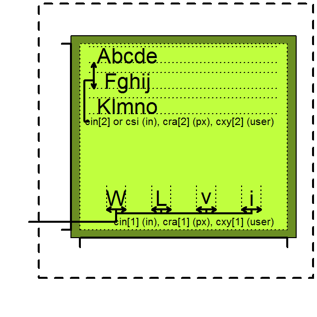

# Step 9d

**par(“cin”)** *(r.o.)* (width, height) in inches

**par(“csi”)** *(r.o.)* height in inches

**par(“cra”)** *(r.o.)* (width, height) in pixels

**par(“cxy”)** *(r.o.)* (width, height) in user coordinates

You can query the approximate size of individual characters using various **par** arguments. Three of these arguments, cin, cra, and cxy, give the size of the width and height as a vector of length 2. The csi argument gives the height only.

The height is the height of a line and the width is the same no matter which letter you choose.

# Step 10a

There is no graph for this step

# Step 10b

## My fonts are too big/too small

Sometimes your fonts will be so large that they overlap each other or crowd out the other information in your graph. Fixing this takes a bit of trial and error. Here are some ways you can revise your graph to get more appropriate font sizes.

1. Trying opening your graphics device with different values for height and width. While most aspects of your graph will scale proportionately, the fonts (and the margins) will remain the same. A larger graphics device size will end up shrinking your fonts relative to the size of the graph and a smaller graphics device size will end up expanding your fonts.
2. Specify a larger/smaller value for the pointsize argument when you open your graphics device.
3. Use the cex argument to increase or decrease the relative size of your fonts.

# Step 11a

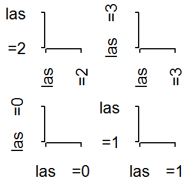

# Step 11b

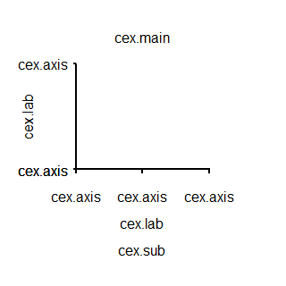

# Step 11c

## Help!! My title or axis labels won’t fit.

There are several possible solutions.

1. You can assign wider margins using the **mar** or **mai** argument in **par**.
2. You can change the orientation of the axis labels with the **las**. Choose among
1. **las=0** both axis labels parallel
2. **las=1** both axis labels horizontal
3. **las=2** both axis labels perpendicular
4. **las=3** both axis labels vertical
3. change the relative size of the font
1. **cex.axis** for the tick mark labels.
2. **cex.lab** for **xlab** and **ylab**.
3. **cex.main** for the main title
4. **cex.sub** for the subtitle.